# Day 1

## Welcome to STAT 240!

- [About me](https://rmshksu.github.io)
- About you!

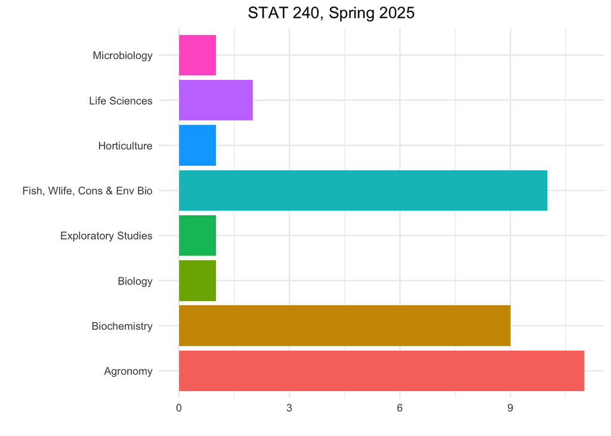

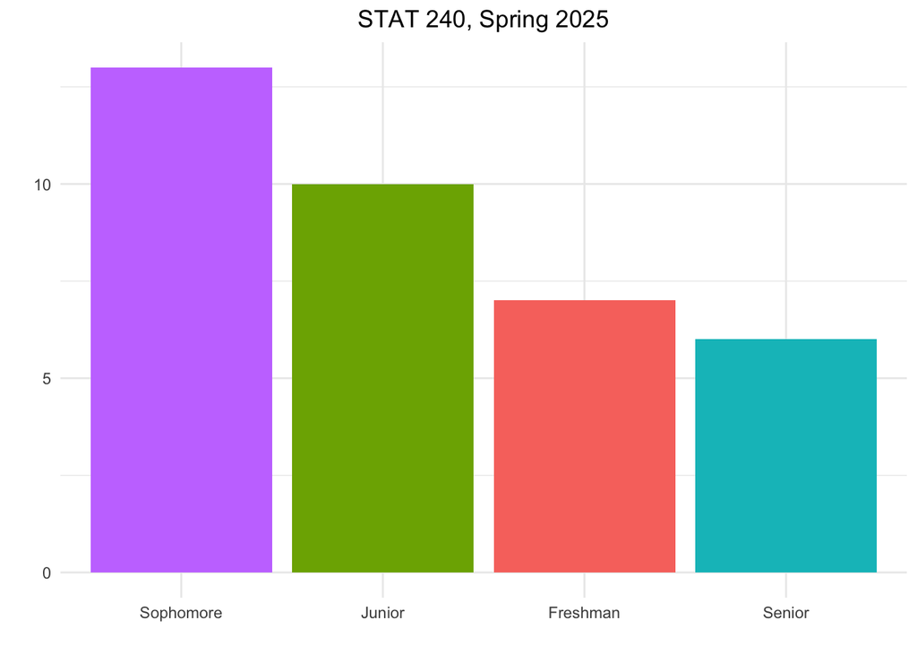

## About this course

### Admin Stuff

- Website
- Office Hours and Help Lab
- Syllabus story time
- “Extra” Math help course

### Philosophy

- Gen Eds
- Pedagogy
- Grades

### Goals

- Statistical Literacy
- Basic Analysis
- (Hopefully) Probabilistic Thinking

**Questions?**

**Goals For Today:**

1. Develop a definition of the science of Statistics
2. Define and describe populations versus samples
3. Define fundamental sampling techniques

## Visualizing Data

### Statistics as a Science

**How many undergraduates are in this room?**

**How many undergraduates are at K-State?**

**How many undergraduates are there in America? The world?**

I want to understand the average caloric intake of undergraduate students in the US.

But I live in Kansas, not the entirety of the US.

How can I find the answer to my question (assuming we don’t know the answer already)?

I resolve to take my research question:

> What is the average caloric intake of undergraduate students in the US?

And hand it over to a 5 different Universities across the US:

- Kansas State University
- UC Davis
- (The) Ohio State University
- UCONN (University of Conneticuit)
- Texas A&M

I tell them to select $200$ students at random and determine their caloric intake.

All in all, I end up with $1000$ students representing the totality of American Undergraduates.

What have I done? I’ve taken a **sample** from my **population.**

- **Population:** the *entire collection* of individuals about which information is sought.
- **Sample:** a *subset* of population, containing the individuals that are actually observed.

I calculate an average from my sample, and I end up finding out *some value* that I use to infer the caloric intake for undergraduates across the entire US.

What have I done? I’ve made *inference* about a *population* from a *sample*; I’ve done **Statistics.**

**Statistics:** is the study of procedures for collecting, describing, and drawing conclusions from information.

> Plainly, the act of describing or making inferences about a population, from a sample

### Parameters and Statistics

*Let’s look at a different example*

Raccoons get rabies, more than normal for most mammals. The Kansas Department of Wildlife & Parks decides to investigate how prevalent rabies is in the state.

KDWP estimates there are roughly $3.3$ million raccoons in Kansas. They capture $10000$ raccoons across the state and test them for rabies. They find 382 raccoons that test positive for rabies, with the rest being negative.

- In this study, what is considered the population?
- What is the sample?
- What does the study tell us about raccoons and rabies in Kansas?

In our study, we had a distinct population and sample, with a distinct quantity for each. This number can be very useful, but is generally *insufficiently informative*.

The Center for Disease Control (CDC) estimates roughly $10$-$14\%$ of raccoons carry *Rabies lyssavirus*. From KDWP’s study, they found that $3.82\%$ of the raccoons in their sample had rabies, and extrpolated that to the entire population.

$${382\over 10000}=0.0382 \times 100 = 3.82\%$$

What we now have are two values that **describe** our population and our sample.

- **Parameter:** a number that describes an entire population.
- **Statistic:** a number that describes a sample.
- What was our parameter in the above study?
- Our statistic?

### Sampling Techniques

I want to know how many individuals in the K-State Division of Biology consider Cell Biology to be an enjoyable class.

I decide to assign every student who’s taken the class and declared a major that falls under the Division of Biology’s umbrella a number from $1$ to $500$ (let’s play some make believe on how many students we’re working with here).

I then generate $50$ random numbers from $1$ to $N$, and select those students to participate in my one question survey.

What I’ve done has resulted in a sample size of $n=50$, where **every individual was equally likely to be selected.**

$$\text{Probability of being selected first} = {1\over 500}$$

Let’s not discuss what happens as each person is selected…

I’ve performed a **Simple Random Sample**.

- **Simple Random Sample (SRS):** a sample chosen by a method in which collection of n population items is equally likely to make up the sample.

Let’s say I divide the $500$ students into two groups: Pre-Med and Not-Pre-Med

I end up with a split of $n_1=300$ Pre-Med students and $n_2=200$ Not-Pre-Med students, then I perform my SRS on each group.

This is a **Stratified Sample**.

- **Stratified Sample:** The population is divided into groups, called **strata**, where the members of each *stratum* are similar in some way. Then a SRS is drawn from each stratum.

Let’s go back to our raccoon example:

KDWP samples those raccoons from pre-defined areas, subsections of Kansas, rather than going across the entirety of Kansas in a big fire line and snatching up suspicious racoons.

Each of those subsections of land are called **clusters**, and the technique we’ve used here is called **Cluster Sampling**.

**Cluster Sampling:** Items are drawn from the population in groups, or clusters.

I drive a Honda Fit, which was built on an assembly line, and part of the process of building that car on an assembly line was something called *quality assurance*.

Considering my car has yet to blow up on me, it seems to have passed the QA check.

Likely because they used a proper sampling technique:

The part of the assembly line that produces the muffler for Honda Fits decides that every day they’ll draw a number, $k$, between $3$ and $6$.

Whatever number they draw is now the first muffler that comes off of the line to be checked for defects. Then they’ll check the $k^{th}$ item moving forward.

They draw the number $4$. So the $4^{th}$ muffler that comes off of the line will be evaluated for possible defects, then every $4$ mufflers after that will also be checked for defects.

This is called **Systematic Sampling.**

- **Systematic Sampling:** a starting point is chosen randomly and then every $k^{th}$ item in the population is selected.

Recall our example with Undergraduate caloric intake:

I instead instruct the $5$ chosen Universities to send the survey to every student’s email inbox. They are given the option on whether or not to participate.

This is naturally called a **Voluntary Response Sample**, due to the participants getting to **choose** whether they are involved or not.

Let’s say I decide to calculate the caloric intake of Undergraduates in the US based off of the students in this classroom.

That’s called a **Sample of Convenience**. It was easy, I could finalize it right now, and it’d be fairly incorrect.